# Exercícios 1

Nome:________________________________

Turma:________________________________

## Banco de Sementes do Solo (3 pts - bimestre)

1. A equação fundamental da biologia populacional de plantas daninhas é (complete a equação):

N<sub>t+1</sub> = N<sub>t</sub> + ____________________ - ____________________ + imigrantes - ____________________ (3 pts)

2. Lembre-se da equação formalizada do banco de sementes:

**N<sub>t+1</sub>** = N<sub>t</sub> + [(N<sub>t</sub> * E<sub>m</sub> * S<sub>pl</sub>) * P * (1-E<sub>f</sub>)] * D - [(N<sub>t</sub> * E<sub>m</sub>) + ((N<sub>t</sub>-N<sub>t</sub> * E<sub>m</sub>) * (1-S<sub>bs</sub>))] + I-E

N<sub>m</sub> = N<sub>t</sub> * E<sub>m</sub> * S<sub>pl</sub>

P = (P<sub>m</sub> * (exp(-a * N<sub>m</sub>)))

Um agrônomo fez uma amostragem em uma lavoura em setembro de 2019 e determinou que havia 900 sementes de picão preto m<sup>-2</sup> no banco de sementes. Usando as informações mostradas na página 3, obtenha valores para cada um dos componentes da equação, conforme mostrado a seguir. Observe que esses dados não presumem nenhum controle de plantas daninhas. Portanto, E<sub>f</sub> = 0. Certifique-se de **incluir unidades** e **mostrar seu trabalho** (4 pontos)

Suponha que D = 0,3 e ignore a imigração e a emigração.

**Dica:** exp(-0,05 * 81,2) = 0,0172

1. N<sub>t</sub> = ________ (1 pt)
2. N<sub>pl</sub> =________ (2 pts)
3. N<sub>m</sub> = ________ (2 pts)
4. P = ________ (2 pts)
5. Emergências = ________ (2 pts)
6. Mortes (perdas) = ________ (3 pts)
7. N<sub>t+1</sub> = ________ (3 pts)

O banco de sementes está aumentando ou diminuindo de tamanho? (1 pt)

3. Suponha que você seja um agrônomo trabalhando para a Cooperativa. Você está discutindo o problema com o produtor e quer ajudar a encontrar uma maneira de reduzir a população de picão preto mais rapidamente.
1. Que tática de manejo você recomendaria para fazer isso acontecer e que taxa(s) variável(is) na equação do banco de sementes essa prática de manejo influenciaria? (2 pts)
2. Qual seria uma mudança razoável no valor dessa variável de taxa e o que causaria essa mudança? (explicar) (2 pts)
3. Usando a mudança argumentada acima em a e b, recalcule N<sub>t+1</sub> (mostre seu trabalho) (4 pts)
4. O banco de sementes aumenta ou diminui (em relação ao tamanho inicial do banco de sementes) com essa mudança? Por quanto? (1 pt)
5. Você está satisfeito com este novo tamanho de banco de sementes (explique)? (1 pt)
6. Quais outras informações precisamos saber mais para tornar este modelo melhor (explique)? (2 pts)

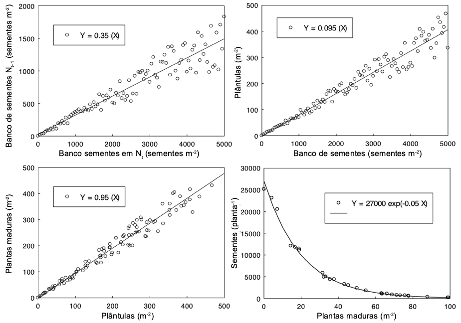